# HDT3-Arboles de decision

Andres Quinto, Mirka Monzon, Oscar De Leon

04/03/2022

```r
datos = read.csv("./train.csv")
test<- read.csv("./test.csv", stringsAsFactors = FALSE)
#Selected rows
housesFilter <-select(datos, LotFrontage, LotArea, YearBuilt, YearRemodAdd, MasVnrArea, BsmtFinSF1,BsmtFinSF2,BsmtUnfSF,TotalBsmtSF,X1stFlrSF,X2ndFlrSF,LowQualFinSF,GrLivArea,TotRmsAbvGrd,Fireplaces,GarageYrBlt,GarageCars,GarageArea,WoodDeckSF,OpenPorchSF,EnclosedPorch,ScreenPorch,PoolArea,MoSold,YrSold,SalePrice)
#Data cleanup
housesFilter <- na.omit(housesFilter)

# Resumen de variables
summary(housesFilter)
```

```
##   LotFrontage        LotArea         YearBuilt     YearRemodAdd
##  Min.   : 21.00   Min.   :  1300   Min.   :1880   Min.   :1950
##  1st Qu.: 60.00   1st Qu.:  7590   1st Qu.:1953   1st Qu.:1966
##  Median : 70.00   Median :  9416   Median :1974   Median :1995
##  Mean   : 70.67   Mean   : 10123   Mean   :1972   Mean   :1986
##  3rd Qu.: 80.00   3rd Qu.: 11361   3rd Qu.:2003   3rd Qu.:2005
##  Max.   :313.00   Max.   :215245   Max.   :2010   Max.   :2010
##    MasVnrArea       BsmtFinSF1       BsmtFinSF2        BsmtUnfSF
##  Min.   :   0.0   Min.   :   0.0   Min.   :   0.00   Min.   :   0.0
##  1st Qu.:   0.0   1st Qu.:   0.0   1st Qu.:   0.00   1st Qu.: 250.0
##  Median :   0.0   Median : 374.0   Median :   0.00   Median : 506.0
##  Mean   : 108.5   Mean   : 438.4   Mean   :  44.59   Mean   : 594.1
##  3rd Qu.: 170.0   3rd Qu.: 702.0   3rd Qu.:   0.00   3rd Qu.: 840.0
##  Max.   :1600.0   Max.   :5644.0   Max.   :1474.00   Max.   :2336.0
##   TotalBsmtSF     X1stFlrSF      X2ndFlrSF       LowQualFinSF
##  Min.   :   0   Min.   : 438   Min.   :   0.0   Min.   :  0.000
##  1st Qu.: 803   1st Qu.: 894   1st Qu.:   0.0   1st Qu.:  0.000
##  Median :1008   Median :1097   Median :   0.0   Median :  0.000
##  Mean   :1077   Mean   :1174   Mean   : 353.3   Mean   :  4.568
##  3rd Qu.:1324   3rd Qu.:1411   3rd Qu.: 728.0   3rd Qu.:  0.000
##  Max.   :6110   Max.   :4692   Max.   :2065.0   Max.   :572.000
##    GrLivArea     TotRmsAbvGrd      Fireplaces      GarageYrBlt
##  Min.   : 438   Min.   : 3.000   Min.   :0.0000   Min.   :1900
##  1st Qu.:1155   1st Qu.: 5.000   1st Qu.:0.0000   1st Qu.:1959
##  Median :1479   Median : 6.000   Median :1.0000   Median :1981
##  Mean   :1531   Mean   : 6.576   Mean   :0.6039   Mean   :1978
##  3rd Qu.:1776   3rd Qu.: 7.000   3rd Qu.:1.0000   3rd Qu.:2003
##  Max.   :5642   Max.   :12.000   Max.   :3.0000   Max.   :2010
##    GarageCars      GarageArea     WoodDeckSF      OpenPorchSF
##  Min.   :1.000   Min.   : 160   Min.   :  0.00   Min.   :  0.00
##  1st Qu.:1.000   1st Qu.: 360   1st Qu.:  0.00   1st Qu.:  0.00
##  Median :2.000   Median : 484   Median :  0.00   Median : 27.00
##  Mean   :1.879   Mean   : 503   Mean   : 92.61   Mean   : 46.13
##  3rd Qu.:2.000   3rd Qu.: 600   3rd Qu.:168.00   3rd Qu.: 68.00
##  Max.   :4.000   Max.   :1418   Max.   :857.00   Max.   :547.00
##  EnclosedPorch     ScreenPorch       PoolArea           MoSold
##  Min.   :  0.00   Min.   :  0.0   Min.   :  0.000   Min.   : 1.00
##  1st Qu.:  0.00   1st Qu.:  0.0   1st Qu.:  0.000   1st Qu.: 5.00
##  Median :  0.00   Median :  0.0   Median :  0.000   Median : 6.00
##  Mean   : 21.84   Mean   : 16.1   Mean   :  2.935   Mean   : 6.34
##  3rd Qu.:  0.00   3rd Qu.:  0.0   3rd Qu.:  0.000   3rd Qu.: 8.00
##  Max.   :552.00   Max.   :480.0   Max.   :648.000   Max.   :12.00
##      YrSold       SalePrice
##  Min.   :2006   Min.   : 35311
##  1st Qu.:2007   1st Qu.:131000
##  Median :2008   Median :164900
##  Mean   :2008   Mean   :185506
##  3rd Qu.:2009   3rd Qu.:219500
##  Max.   :2010   Max.   :755000
```

Hoja de trabajo #3 - Arboles de dicision

2. Haga un análisis exploratorio extenso de los datos. Explique bien todos los hallazgos. No ponga solo gráficas y código. Debe llegar a conclusiones interesantes para poder predecir. Explique el preprocesamiento que necesitó hacer

## Graficas para cada una de las variables.

### Variable LotFrontage

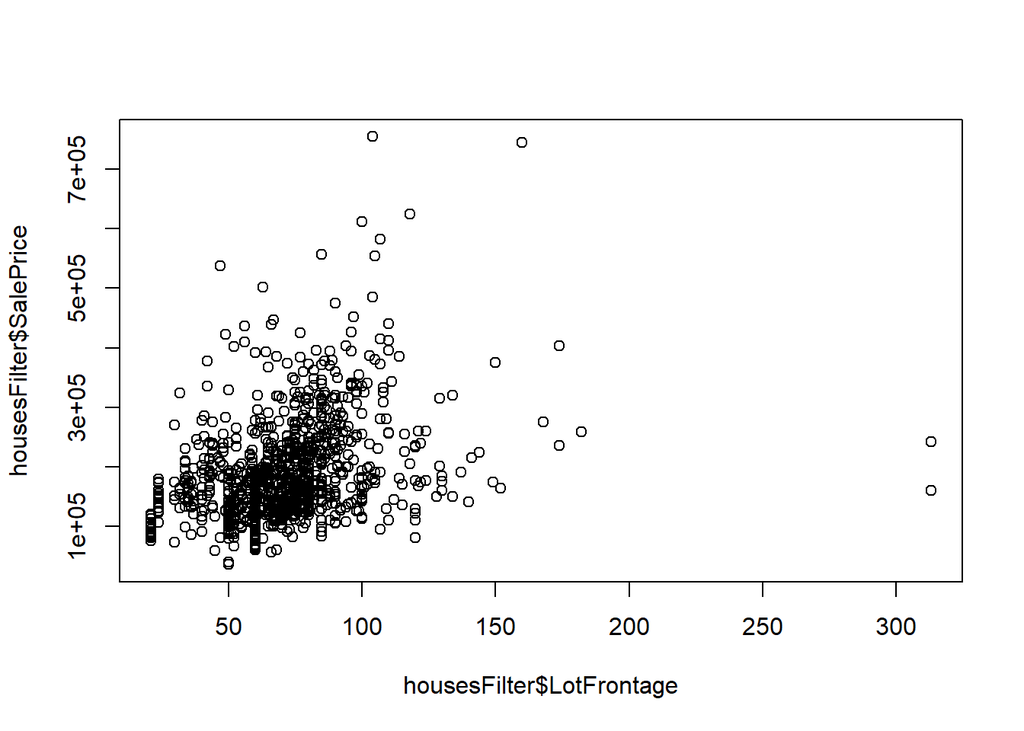

```r
plot(housesFilter$LotFrontage, housesFilter$SalePrice)
```

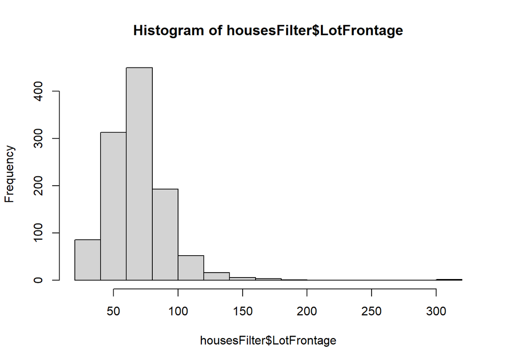

```r
hist(housesFilter$LotFrontage)
```

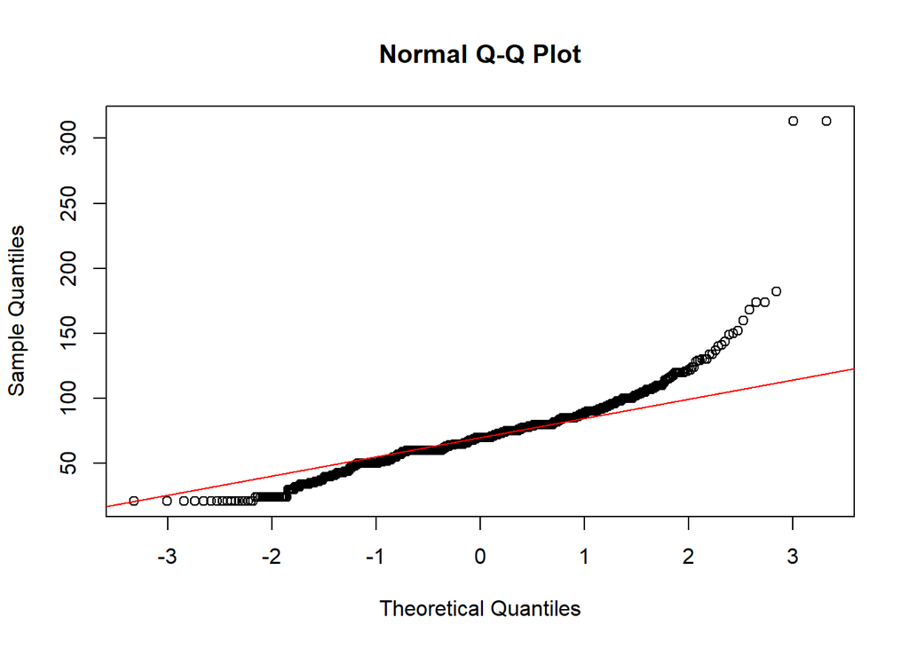

```r
qqnorm(housesFilter$LotFrontage)
qqline(housesFilter$LotFrontage, col='red')
```

#### Esta variable describe: los metros lineales de la calle conectados a la propiedad. cuenta con un sesgo positivo, los datos estan ligeramente normalizados y no tienen una relacion directa con el precio de venta.

### Variable LotArea

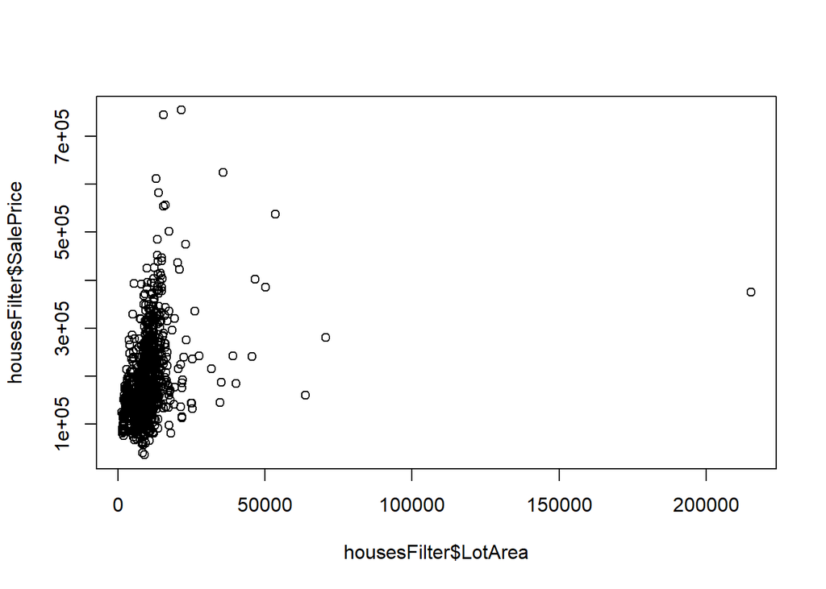

```r
plot(housesFilter$LotArea, housesFilter$SalePrice)
```

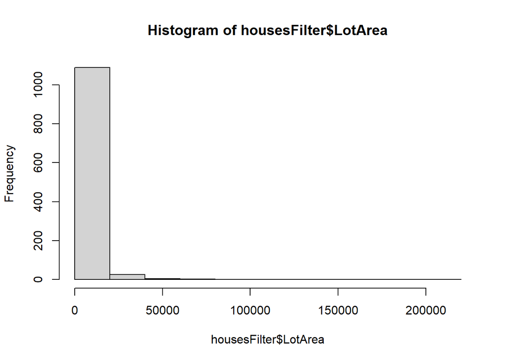

```r
hist(housesFilter$LotArea)
```

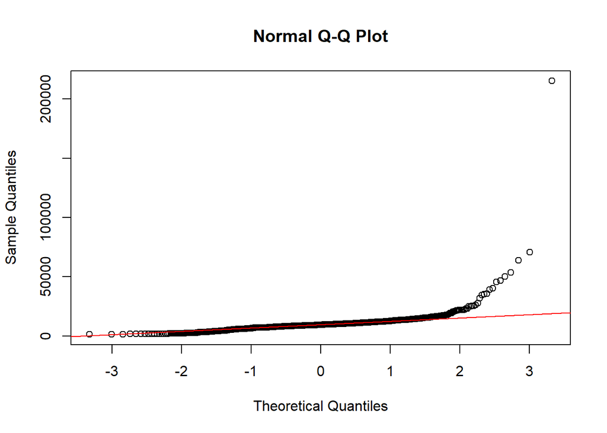

```r
qqnorm(housesFilter$LotArea)
qqline(housesFilter$LotArea, col='red')
```

#### Esta variable describe el tamaño del lote en mtros cuadrado. Cuenta con un sesgo positivo, pero los datos no están del todo normalizados por lo que no tienen una relacion directa con el precio de venta

### Variable YearBuilt

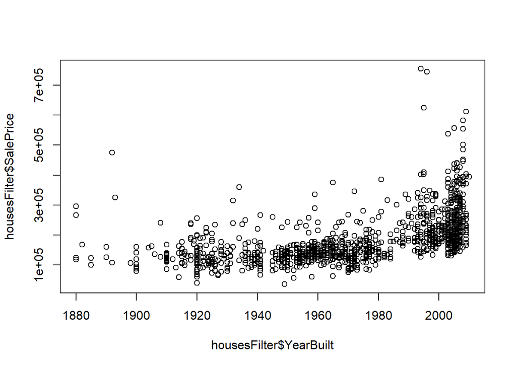

```r
plot(housesFilter$YearBuilt,  housesFilter$SalePrice)
```

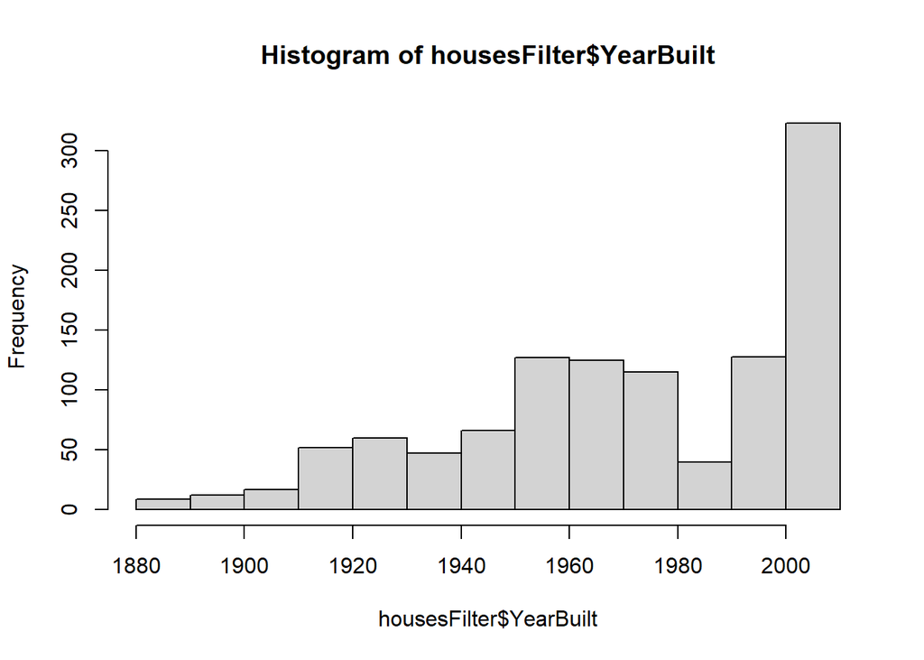

```r
hist(housesFilter$YearBuilt)
```

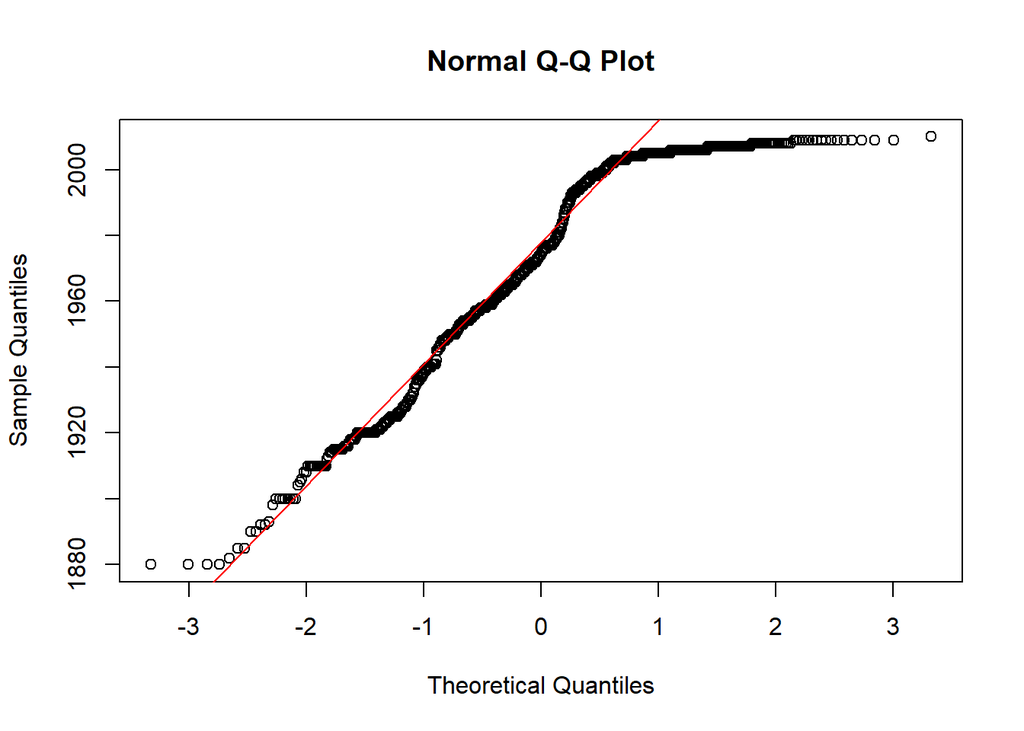

```r
qqnorm(housesFilter$YearBuilt)
qqline(housesFilter$YearBuilt, col='red')
```

##### Esta variable describe el año de construccion. Cuenta con un sesgo negativo, pero los datos están normalizados en una porción de datos y se puede decir que en los ultimo años se ha aumentado el precio de venta.

### Variable YearRemoAdd

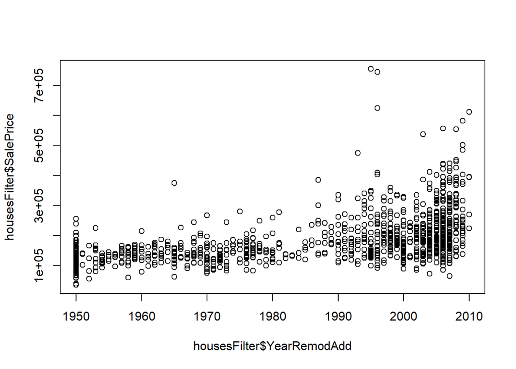

```r
plot(housesFilter$YearRemodAdd,  housesFilter$SalePrice)
```

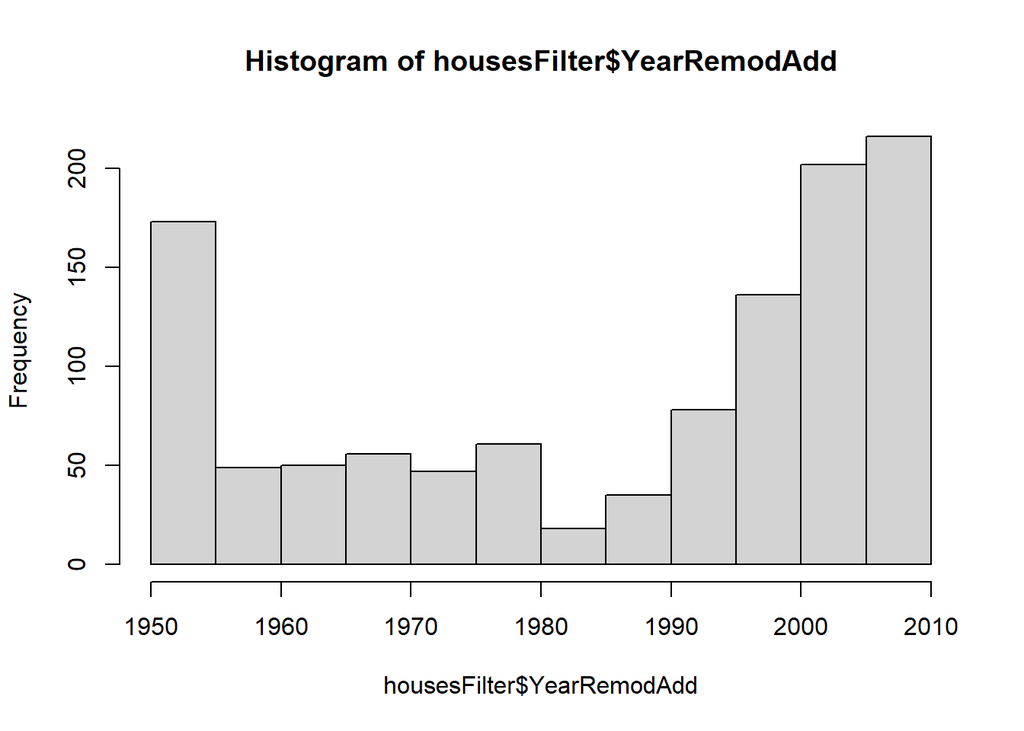

```r
hist(housesFilter$YearRemodAdd)
```

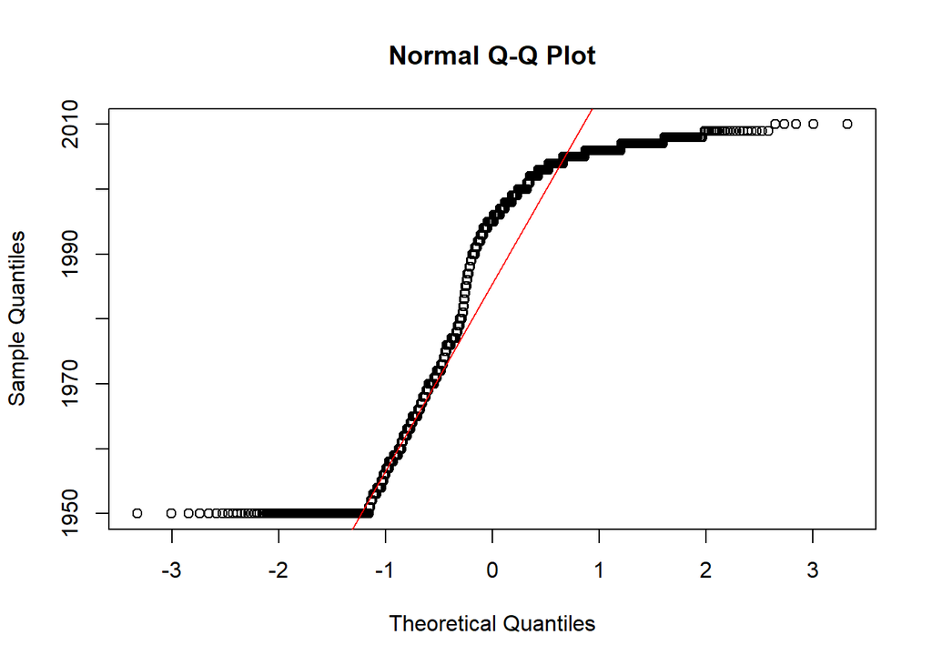

```r
qqnorm(housesFilter$YearRemodAdd)
qqline(housesFilter$YearRemodAdd, col='red')
```

### Variable MasVnArea

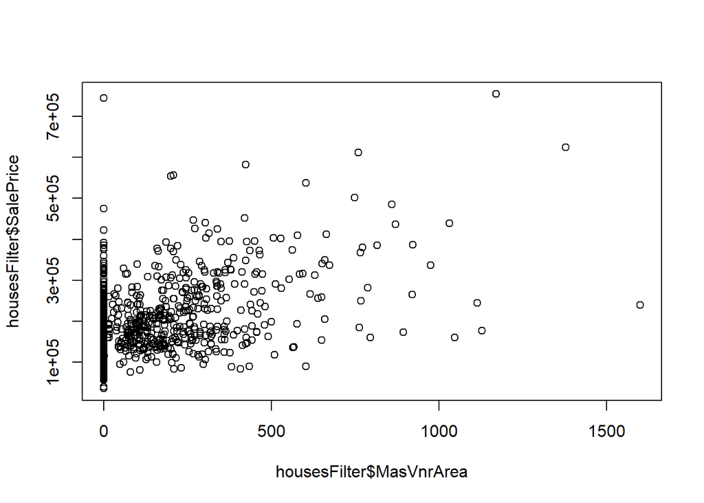

```r
plot(housesFilter$MasVnrArea,  housesFilter$SalePrice)
```

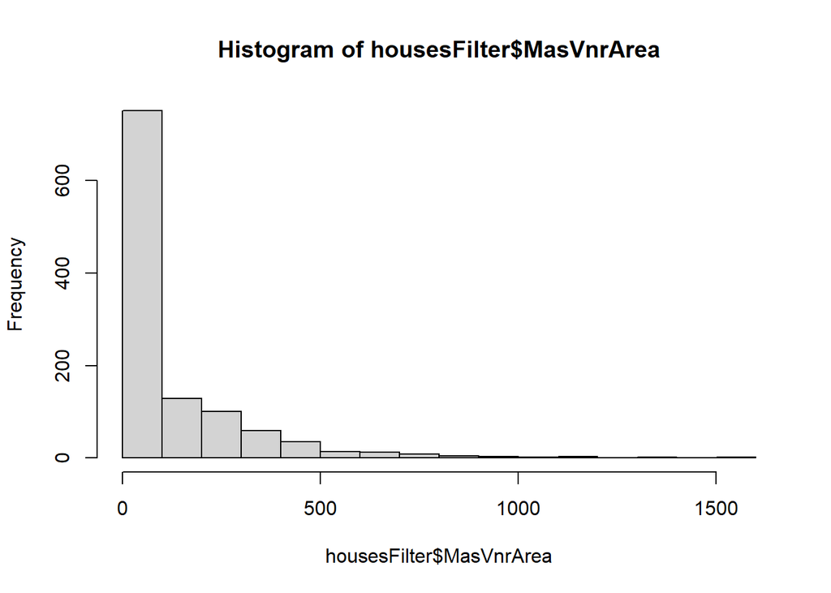

```r
hist(housesFilter$MasVnrArea)
```

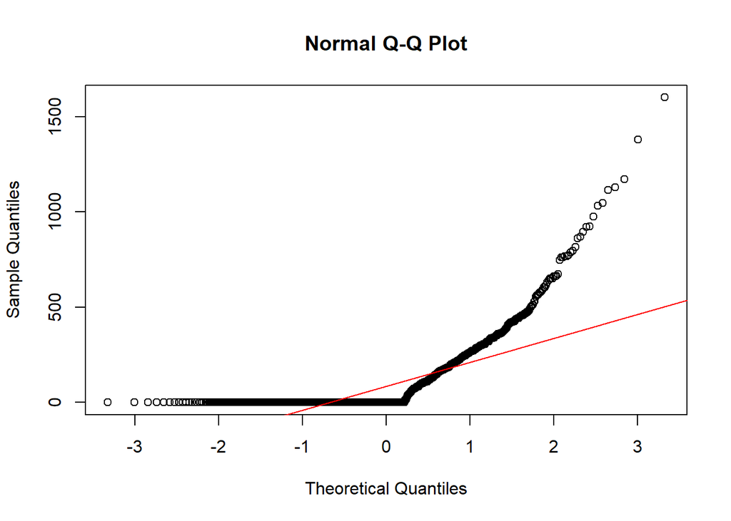

```r
qqnorm(housesFilter$MasVnrArea)
qqline(housesFilter$MasVnrArea, col='red')
```

#### Se muestra con un sesgo positivo pero los dato no estan normalizdos, por lo cual no tienen una relación directa con el precio de venta. (importante)

### Variable BsmFinSF1.

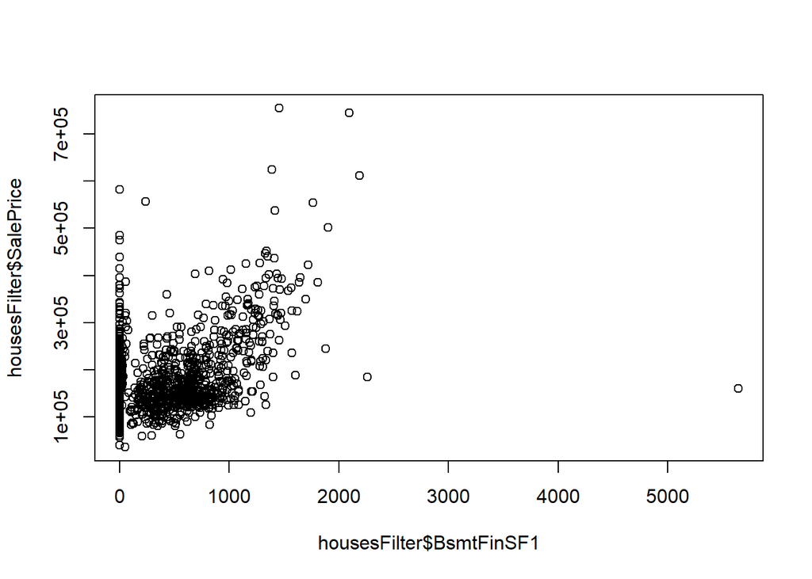

```r
plot(housesFilter$BsmtFinSF1, housesFilter$SalePrice)
```

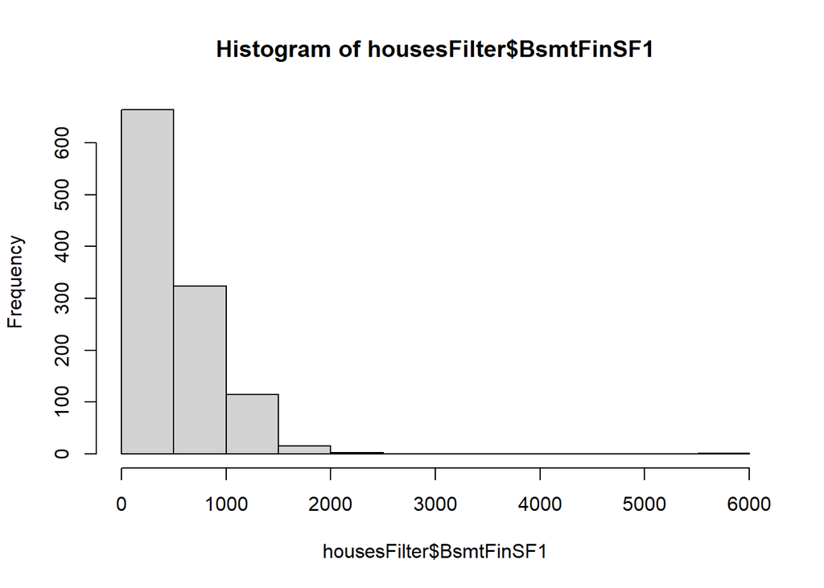

```r
hist(housesFilter$BsmtFinSF1)
```

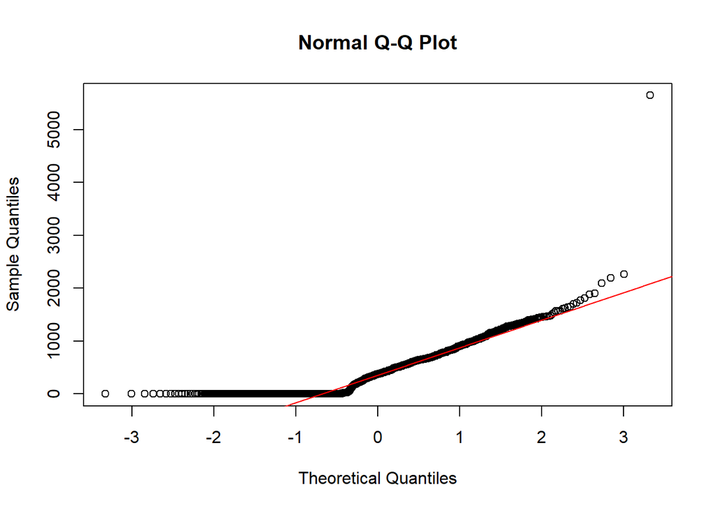

```r
qqnorm(housesFilter$BsmtFinSF1)
qqline(housesFilter$BsmtFinSF1, col='red')
```

### Variable BsmFinSF2.

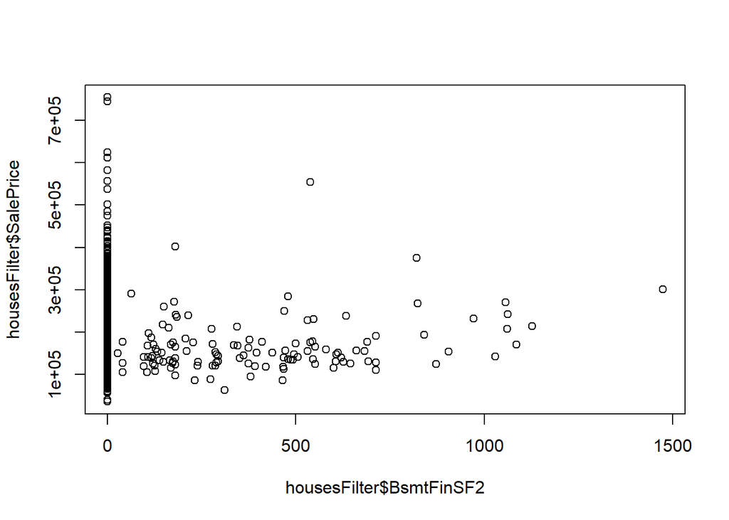

```r
plot(housesFilter$BsmtFinSF2, housesFilter$SalePrice)
```

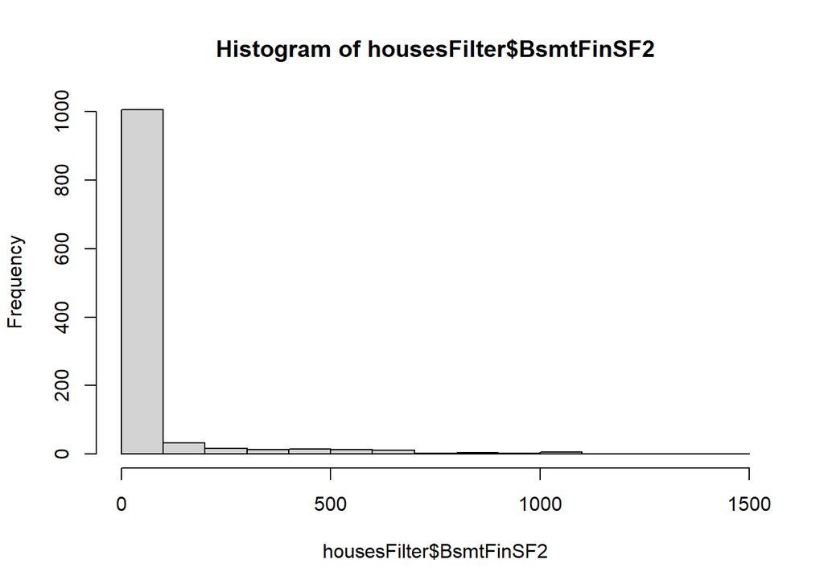

```r
hist(housesFilter$BsmtFinSF2)
```

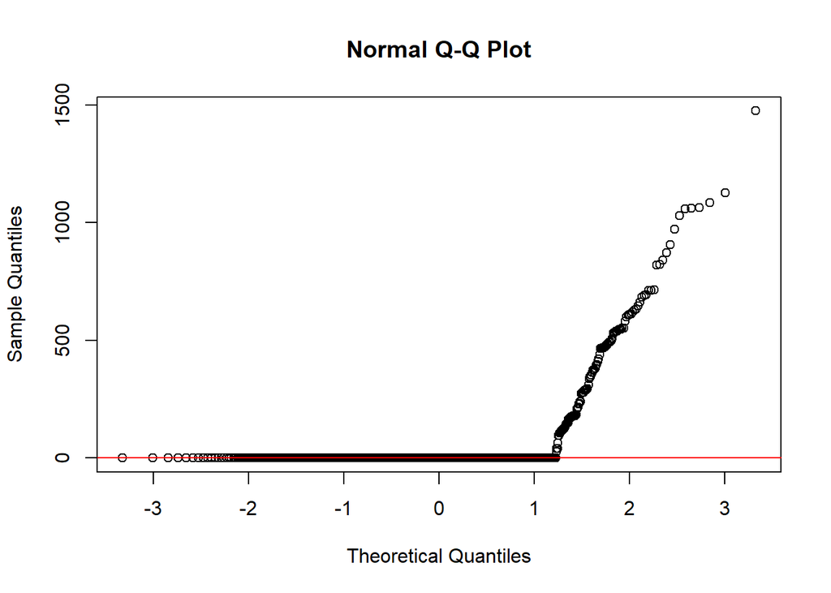

```r
qqnorm(housesFilter$BsmtFinSF2)
qqline(housesFilter$BsmtFinSF2, col='red')
```

#### Esta variable indica los metros cuadrados terminados de tipo 2. Muestra un sesgo positivo, pero los datos no están normalizados por lo que no tiene una relacion directa con el precio de venta.

### Variable BsmtUnfSF

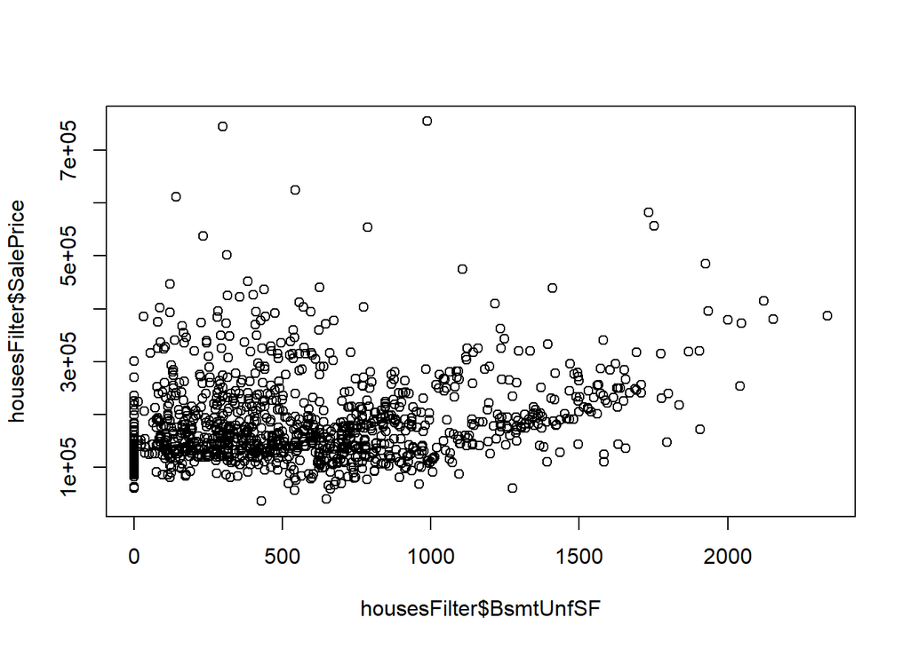

```r
plot(housesFilter$BsmtUnfSF, housesFilter$SalePrice)
```

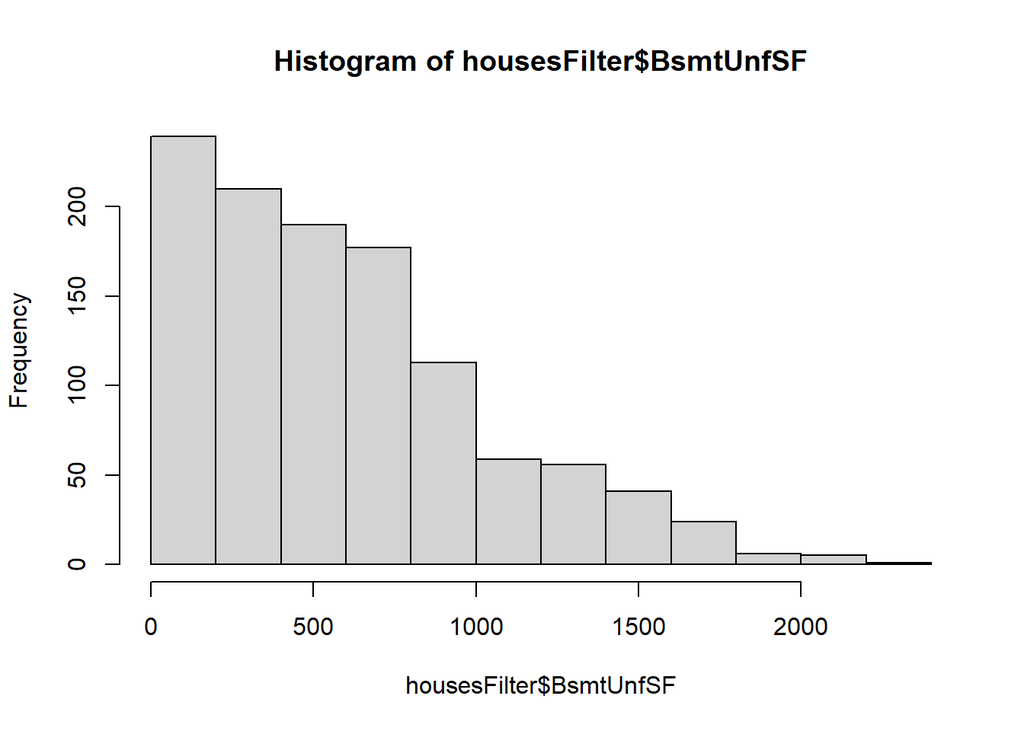

```r
hist(housesFilter$BsmtUnfSF)
```

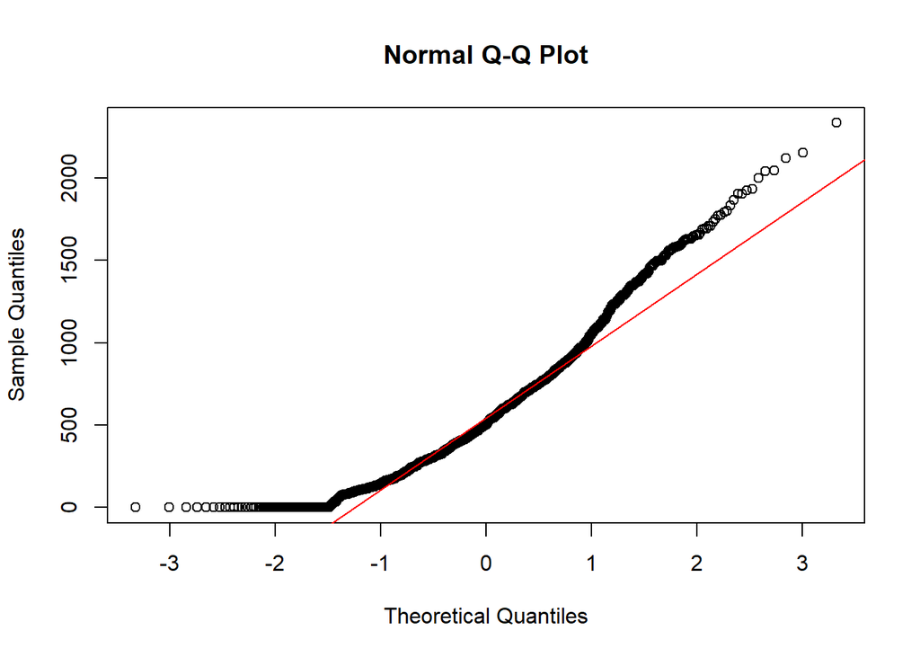

```r
qqnorm(housesFilter$BsmtUnfSF)
qqline(housesFilter$BsmtUnfSF, col='red')
```

#### Esta variable muestra en la grafica un sesgo positivo y los datos se muestran normalizados, por lo que la relacion con el precio de venta es muy pequeña.

### Variable TotalBsmtSF

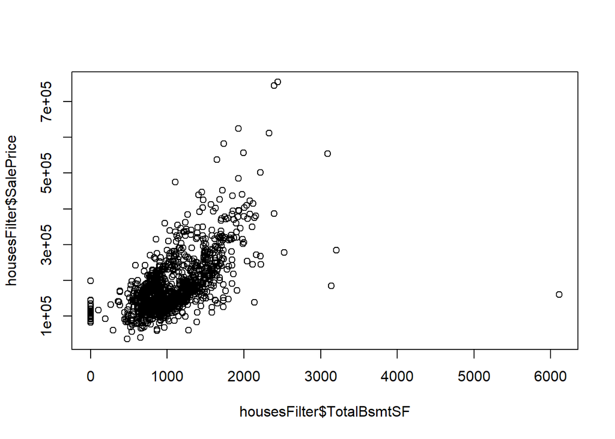

```r
plot(housesFilter$TotalBsmtSF, housesFilter$SalePrice)
```

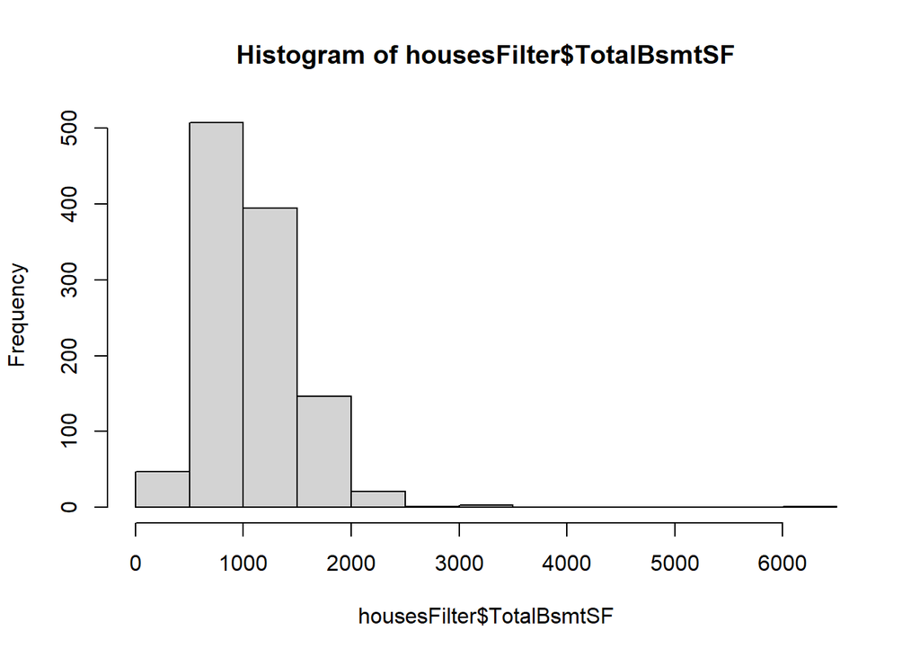

```r
hist(housesFilter$TotalBsmtSF)
```

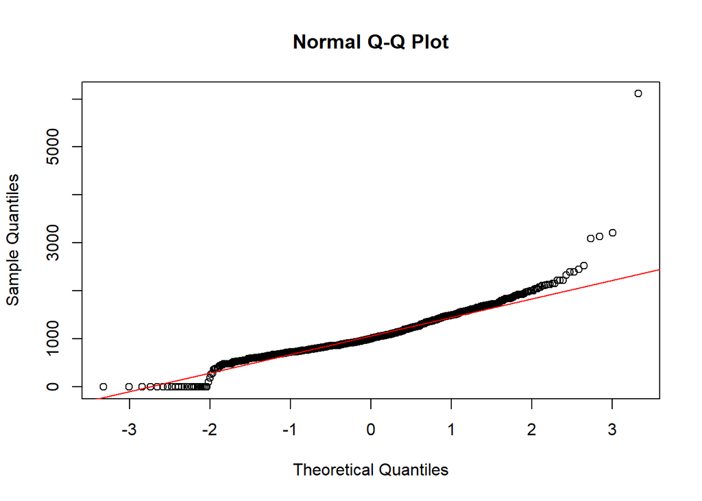

```r
qqnorm(housesFilter$TotalBsmtSF)
qqline(housesFilter$TotalBsmtSF, col='red')
```

#### La variable describe los metros cuadradso totales de un sótano. Ademas la variable muestra un poco de simetría y los datos se muestran normalizados. Por lo que si tienen una relación directa con el precio de venta.

### Variable X1stFlrSF

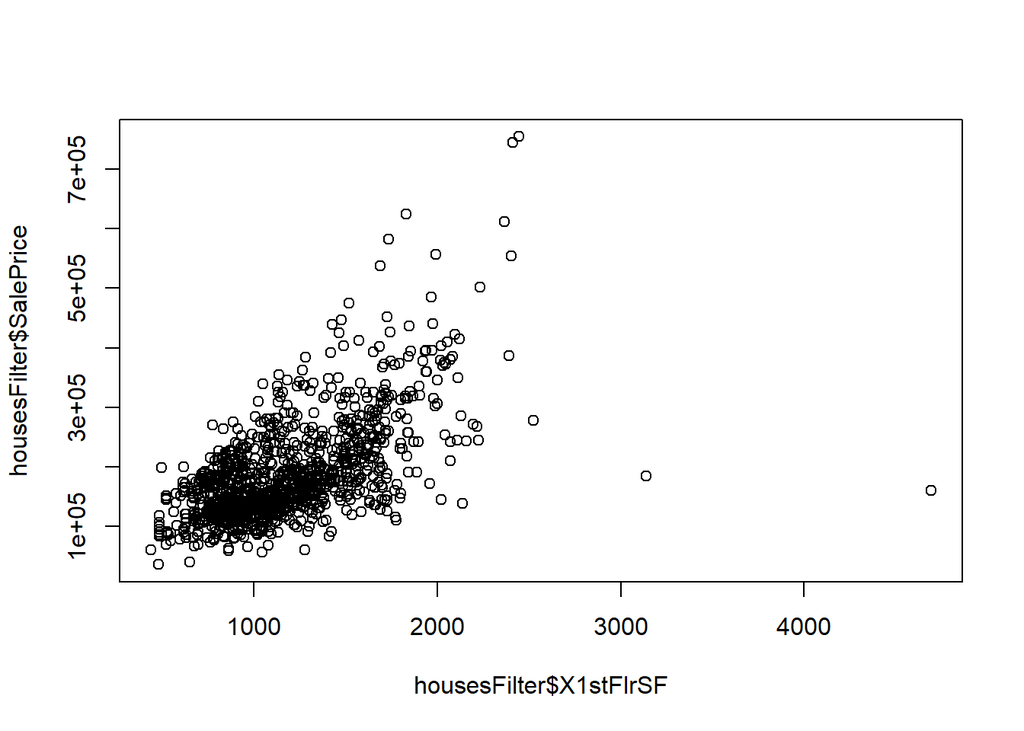

```r
plot(housesFilter$X1stFlrSF, housesFilter$SalePrice)
```

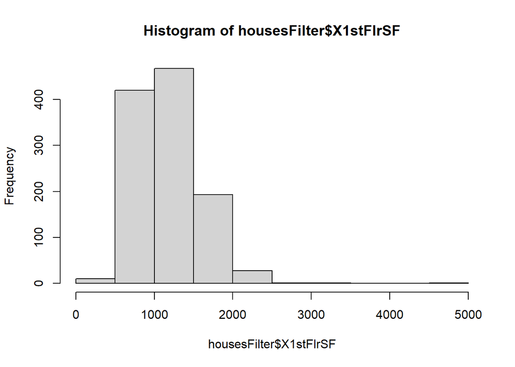

```r
hist(housesFilter$X1stFlrSF)
```

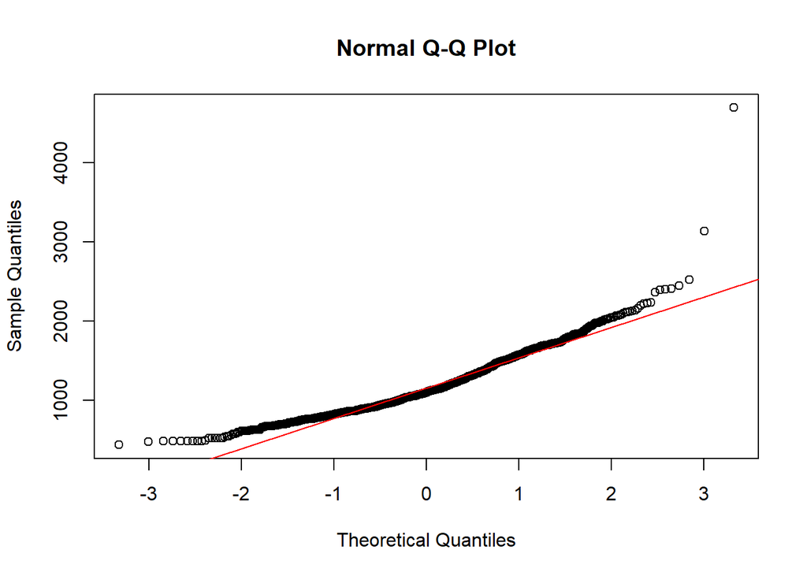

```r
qqnorm(housesFilter$X1stFlrSF)
qqline(housesFilter$X1stFlrSF, col='red')
```

#### Esta variable representa los metros cuadrados del primer piso. La variable muestra poca simetria y los datos se muestran normalizados, por lo que si tiene una relación directa con el precio de venta.